# A compilation of replications of the Diener et al.2010 paper

Theodore Rogers, Olivia Costa, Quincey Feragen, Penelope Corbett

2026-01-27

**README** Below is the script for the Diener et al. (2010) data paper. We recommend to download the “Diener_et_al_replication_data.csv” from the OSF or GitHub pages and run the script to access the cleaned dataset. However, the clean dataset is provided in the OSF and GitHub pages titled “cleaned_diener_et_al_dataset.csv”.

Packages needed:

```r
library(ggplot2)
library(tidyr)
library(dplyr)
library(tidyverse)
library(ltm)
library(gridExtra)
library(rmarkdown)
```

Reading excel spreadsheet

creating data frame, the original data frame (big_data) is left untouched

```r
dat <- big_data
#view(dat)
dat = cbind.data.frame(big_data)
```

Changing values to their categorical variables

```r
#ladder
ladder <- as.factor(dat$ladder)
dat$ladder <- ladder

convert_yes_no <- function(column) {
  column <- as.character(column)
  column[column == "1"] <- "yes"
  column[column == "2"] <- "no"
  return(column)
}

dat[3:8] <- lapply(dat[3:8], convert_yes_no)
dat[11:16] <- lapply(dat[11:16], convert_yes_no)
dat[19:23] <- lapply(dat[19:23], convert_yes_no)

# gender
dat$gender[dat$gender == "1"] <- "woman"
dat$gender[dat$gender == "2"] <- "man"
dat$gender[dat$gender == "3"] <- "nonbinary"
dat$gender[dat$gender == "4"] <- NA
# maritalStatus
dat$maritalStatus[dat$maritalStatus == "1"] <- "married"
dat$maritalStatus[dat$maritalStatus == "2"] <- "domestic partnership"
dat$maritalStatus[dat$maritalStatus == "3"] <- "single"
dat$maritalStatus[dat$maritalStatus == "4"] <- "divorced or separated"
dat$maritalStatus[dat$maritalStatus == "5"] <- "widowed"
dat$maritalStatus[dat$maritalStatus == "6"] <- NA

# residentialArea
dat$residentialArea[dat$residentialArea == "1"] <- "rural"
dat$residentialArea[dat$residentialArea == "2"] <- "village"
dat$residentialArea[dat$residentialArea == "3"] <- "urban_city"
dat$residentialArea[dat$residentialArea == "4"] <- "suburban"

# education
dat$education[dat$education == "1"] <- "primary or less"
dat$education[dat$education == "2"] <- "secondary"
dat$education[dat$education == "3"] <- "some teriary"
dat$education[dat$education == "4"] <- "full teritary"
dat$education[dat$education == "5"] <- "graduate degree"
dat$education[dat$education == "6"] <- "other"

#Cleaning Income Data
dat$income <- as.character(dat$income)
dat$income[dat$income %in% c("NA", ".")] <- NA
dat$income <- as.numeric(dat$income)
```

```r
dat <- dat %>%
  mutate(
    raw_income = readr::parse_number(as.character(income)),
    income = case_when(
      dataSet == "HongKong" ~ raw_income * 0.13,
      dataSet == "vienna"   ~ raw_income * 1.09,
      dataSet %in% c("toronto", "202psy") ~ raw_income * 0.73,
      TRUE ~ raw_income
    )
  )

#Sanity check to make sure no rows were missed in the above conversion. All good!
dat %>%
  filter(
    !dataSet %in% c(
      "HongKong", "vienna", "toronto", "202psy",
      "2018spring", "psy250.", "hatton", "haneda", "2019replication"
    )
  ) %>%
  count(dataSet)
```

```
## [1] dataSet n
## <0 rows> (or 0-length row.names)
```

```r
#Sanity check income ranges
dat %>%
  group_by(dataSet) %>%
  summarize(
    n = n(),
    na_income = sum(is.na(income)),
    min_income = min(income, na.rm = TRUE),
    median_income = median(income, na.rm = TRUE),
    max_income = max(income, na.rm = TRUE)
  )
```

```
## # A tibble: 9 × 6
##   dataSet             n na_income min_income median_income max_income
##   <chr>           <int>     <int>      <dbl>         <dbl>      <dbl>
## 1 2018spring        213        63          0         70000    2000000
## 2 2019replication   183        46          0         75000  500000000
## 3 202psy             29         0          0         17520     292000
## 4 HongKong          200         7          0         23400     520000
## 5 haneda             99        22        100         80000     500000
## 6 hatton            100        48          0         13550     100000
## 7 psy250.           127        48          0         50000   10000000
## 8 toronto            57         0          0          3650     219000
## 9 vienna            163        24          0         16350     195110
```

Cleaning the variables in the data frame, and coding them in accordance with the replication survey values.

```r
positive_vars <- c("enjoyment", "smileLaugh", "respect", "learn", "opportunity", "livingStandard", "emergency", "time", "food", "shelter", "internetAccess", "computer", "television")

#Recode function for yes/nmo -> 1/0 (positive)
for (var in positive_vars){
  vals <- unique(dat[[var]])

  if (any(c("yes", "no") %in% vals)) {
    dat[[var]] <- as.numeric(dplyr::recode(tolower(as.character(dat[[var]])), "yes" = 1, "no"= 0, .default = NA_real_))
  }else{
    message(paste("Skipping", var, "no-not in yes/no format"))
  }
}

#Recode function for yes/nmo -> -1/0 (positive)
negative_vars <- c("sadness", "anger", "depression", "worry")

for (var in negative_vars){
  vals <- unique(dat[[var]])

  if (any(c("yes", "no") %in% vals)) {
    dat[[var]] <- as.numeric(dplyr::recode(tolower(as.character(dat[[var]])), "yes" = -1, "no"= 0, .default = NA_real_))
  }else{
    message(paste("Skipping", var, "no-not in yes/no format"))
  }
}
```

Cleaning the variables in the data frame, and coding them in accordance with the replication survey values.

```r
#Average smileLaugh and enjoyment into Positive feelings column
dat$PositiveFeelings <- rowMeans(dat[, c("smileLaugh", "enjoyment")], na.rm = TRUE)

#Average worry, sadness, depression, and anger into Negative feelings column
dat$NegativeFeelings <- rowMeans(dat[, c("worry", "sadness", "depression", "anger")], na.rm = TRUE)

#Create another column with logIncome
dat$logIncome <- ifelse(!is.na(dat$income) & dat$income > 0,
                        log(dat$income),
                        NA_real_)

#Create another column of luxury conveniences
dat$LuxuryConveniences <- rowMeans(dat[, c("television", "internetAccess", "computer")], na.rm = TRUE)

#Create another column of basic needs
dat$BasicNeeds <- rowMeans(dat[, c("food", "shelter")], na.rm = TRUE)

#Create another column of psych needs
dat$PsychNeeds <- rowMeans(dat[, c("respect", "learn", "opportunity", "time", "emergency")], na.rm = TRUE)
```

Renaming study site variables for cleanliness

```r
dat <- dat %>%
  dplyr::mutate(
    study_site = dplyr::case_when(
      dataSet == "toronto" ~ "Study_Site_1",
      dataSet == "vienna" ~ "Study_Site_2",
      dataSet == "2018spring" ~ "Study_Site_3",
      dataSet == "2019replication" ~ "Study_Site_4",
      dataSet == "psy250." ~ "Study_Site_5",
      dataSet == "HongKong" ~ "Study_Site_6",
      dataSet == "hatton" ~ "Study_Site_7",
      dataSet == "202psy" ~ "Study_Site_8",
      dataSet == "haneda" ~ "Study_Site_9",
      TRUE ~ NA_character_
    )
  )
class(dat$study_site)
```

```
## [1] "character"
```

Demographics per study site made into tables

```r
#Sanity check on age
dat <- dat %>%
  mutate(
    age = readr::parse_number(as.character(age))
  )

#Numeric demographics table (age & income)
numeric_demographics_table <- dat %>%
  dplyr::group_by(study_site) %>%
  dplyr::summarize(
    n = n(),

    age_n = sum(!is.na(age)),
    age_mean   = if (age_n > 0) mean(age, na.rm = TRUE) else NA_real_,
    age_median = if (age_n > 0) median(age, na.rm = TRUE) else NA_real_,
    age_min    = if (age_n > 0) min(age, na.rm = TRUE) else NA_real_,
    age_max    = if (age_n > 0) max(age, na.rm = TRUE) else NA_real_,

    income_n = sum(!is.na(income)),
    income_mean   = if (income_n > 0) mean(income, na.rm = TRUE) else NA_real_,
    income_median = if (income_n > 0) median(income, na.rm = TRUE) else NA_real_,
    income_min    = if (income_n > 0) min(income, na.rm = TRUE) else NA_real_,
    income_max    = if (income_n > 0) max(income, na.rm = TRUE) else NA_real_,

    .groups = "drop"
  )

#Categorical demographics table (counts & proportions)
categorical_demographics <- dat %>%
  dplyr::select(study_site, gender, maritalStatus, residentialArea, education) %>%
  pivot_longer(
    cols = c(gender, maritalStatus, residentialArea, education),
    names_to = "variable",
    values_to = "value"
  ) %>%
  dplyr::mutate(
    value = as.character(value),
    value = if_else(is.na(value) | trimws(value) == "", "Missing", value)
  ) %>%
  count(study_site, variable, value, name = "n") %>%
  group_by(study_site, variable) %>%
  mutate(prop = n / sum(n)) %>%
  ungroup() %>%
  arrange(study_site, variable, desc(n))

#Which study sites are missing whole fields?
missingness <- dat %>%
  group_by(study_site) %>%
  summarize(
    age_missing = mean(is.na(age)),
    gender_missing = mean(is.na(gender)),
    marital_missing = mean(is.na(maritalStatus)),
    resarea_missing = mean(is.na(residentialArea)),
    education_missing = mean(is.na(education)),
    income_missing = mean(is.na(income)),
    .groups = "drop"
  ) %>%
  arrange(desc(age_missing), desc(income_missing))

#Viewing results
numeric_demographics_table
```

```
## # A tibble: 9 × 12
##   study_site       n age_n age_mean age_median age_min age_max income_n
##   <chr>        <int> <int>    <dbl>      <dbl>   <dbl>   <dbl>    <int>
## 1 Study_Site_1    57    56     22.1       20        18      47       57
## 2 Study_Site_2   163   161     24.4       24        19      39      139
## 3 Study_Site_3   213   190     21.4       20        18      50      150
## 4 Study_Site_4   183   174     21.1       20        18      54      137
## 5 Study_Site_5   127   116     21.6       21        19      52       79
## 6 Study_Site_6   200     0     NA         NA        NA      NA      193
## 7 Study_Site_7   100     0     NA         NA        NA      NA       52
## 8 Study_Site_8    29    28     20.6       19.5      19      48       29
## 9 Study_Site_9    99    99     26.2       20        16      79       77
## # ℹ 4 more variables: income_mean <dbl>, income_median <dbl>, income_min <dbl>,
## #   income_max <dbl>
```

```r
categorical_demographics
```

```
## # A tibble: 119 × 5
##    study_site   variable      value               n   prop
##    <chr>        <chr>         <chr>           <int>  <dbl>
##  1 Study_Site_1 education     some teriary       30 0.526
##  2 Study_Site_1 education     secondary          17 0.298
##  3 Study_Site_1 education     full teritary       5 0.0877
##  4 Study_Site_1 education     graduate degree     4 0.0702
##  5 Study_Site_1 education     Missing             1 0.0175
##  6 Study_Site_1 gender        woman              38 0.667
##  7 Study_Site_1 gender        man                14 0.246
##  8 Study_Site_1 gender        Missing             3 0.0526
##  9 Study_Site_1 gender        nonbinary           2 0.0351
## 10 Study_Site_1 maritalStatus single             42 0.737
## # ℹ 109 more rows
```

```r
missingness
```

```
## # A tibble: 9 × 7
##   study_site   age_missing gender_missing marital_missing resarea_missing
##   <chr>              <dbl>          <dbl>           <dbl>           <dbl>
## 1 Study_Site_7      1             0.03            1                1
## 2 Study_Site_6      1             0               1                1
## 3 Study_Site_3      0.108         0.0986          0.136            0.0986
## 4 Study_Site_5      0.0866        0.00787         1                1
## 5 Study_Site_4      0.0492        0.0546          0.0601           0.0492
## 6 Study_Site_8      0.0345        0               0.0345           0
## 7 Study_Site_1      0.0175        0.0526          0.0526           0.0175
## 8 Study_Site_2      0.0123        0               0.00613          0.0123
## 9 Study_Site_9      0             0               0.0303           0
## # ℹ 2 more variables: education_missing <dbl>, income_missing <dbl>
```

**Prepping for analyses:** There will be two data frames, one with all participants (N = 1171), and the other that has all the NAs omitted across the dataframe. This was done, as a part of a previous project. That used a smaller dataset.

```r
dat <- dat %>%
  dplyr::mutate(
    ladder = readr::parse_number(na_if(as.character(ladder), "NaN")),
    PositiveFeelings = readr::parse_number(na_if(as.character(PositiveFeelings), "NaN")),
    NegativeFeelings = readr::parse_number(na_if(as.character(NegativeFeelings), "NaN"))
  )

#Creating the omitted NAs data frame: this was used in the poster and other subsequent analyses, however, it is now its own data frame and you will be able to use Dat for the analyses below.
dat_na_omit <- dat[complete.cases(dat), ] #N = 342 (whereas Dat has N = 1171)
```

**Sample Analyses** For these analyses, I have dropped NAs in the columns we care about for these analyses and not overall throughout the whole data frame. To keep the sample consistent model to model.

Creating the models for the predictor variables (basic needs, psych needs, luxury conveniences, standard of living, and log income)

```r
f_basic  <- ladder ~ BasicNeeds
f_psych  <- ladder ~ BasicNeeds + PsychNeeds
f_lux    <- ladder ~ BasicNeeds + PsychNeeds + LuxuryConveniences + livingStandard
f_income <- ladder ~ BasicNeeds + PsychNeeds + LuxuryConveniences + livingStandard + logIncome

#Creating NA-datasets for each model
dat_basic  <- dat %>% drop_na(all.vars(f_basic))
dat_psych  <- dat %>% drop_na(all.vars(f_psych))
dat_lux    <- dat %>% drop_na(all.vars(f_lux))
dat_income <- dat %>% drop_na(all.vars(f_income))

#Make sure the N is locked in before running anything
data.frame(
  mode_spec = c("BasicNeeds", "PsychNeeds", "Luxury", "Income"),
  N = c(nrow(dat_basic), nrow(dat_psych), nrow(dat_lux), nrow(dat_income))
)
```

```
##    mode_spec   N
## 1 BasicNeeds 915
## 2 PsychNeeds 914
## 3     Luxury 914
## 4     Income 683
```

```r
#Fitting models to the clean datasets
wellbeingBasicNeedsModel <- lm(f_basic,  data = dat_basic)
wellbeingPsychNeedsModel <- lm(f_psych,  data = dat_psych)
wellbeingLuxuryModel     <- lm(f_lux,    data = dat_lux)
wellbeingIncomeModel     <- lm(f_income, data = dat_income)

#Summaries
summary(wellbeingBasicNeedsModel)
```

```
##
## Call:
## lm(formula = f_basic, data = dat_basic)
##
## Residuals:
##     Min      1Q  Median      3Q     Max
## -5.8581 -0.8581  0.1419  1.1419  5.3870
##
## Coefficients:
##             Estimate Std. Error t value Pr(>|t|)
## (Intercept)  6.85814    0.06638 103.309  < 2e-16 ***
## BasicNeeds  -1.24509    0.19597  -6.354 3.32e-10 ***
## ---
## Signif. codes:  0 '***' 0.001 '**' 0.01 '*' 0.05 '.' 0.1 ' ' 1
##
## Residual standard error: 1.704 on 913 degrees of freedom
## Multiple R-squared:  0.04234,    Adjusted R-squared:  0.04129
## F-statistic: 40.37 on 1 and 913 DF,  p-value: 3.315e-10
```

```r
summary(wellbeingPsychNeedsModel)
```

```
##
## Call:
## lm(formula = f_psych, data = dat_psych)
##
## Residuals:
##     Min      1Q  Median      3Q     Max
## -6.1072 -0.8876  0.1601  1.1601  5.0384
##
## Coefficients:
##             Estimate Std. Error t value Pr(>|t|)
## (Intercept)   5.7703     0.2173  26.553  < 2e-16 ***
## BasicNeeds   -0.8782     0.2033  -4.321 1.73e-05 ***
## PsychNeeds    1.3369     0.2544   5.256 1.84e-07 ***
## ---
## Signif. codes:  0 '***' 0.001 '**' 0.01 '*' 0.05 '.' 0.1 ' ' 1
##
## Residual standard error: 1.672 on 911 degrees of freedom
## Multiple R-squared:  0.06947,    Adjusted R-squared:  0.06743
## F-statistic: 34.01 on 2 and 911 DF,  p-value: 5.704e-15
```

```r
summary(wellbeingLuxuryModel)
```

```
##
## Call:
## lm(formula = f_lux, data = dat_lux)
##
## Residuals:
##     Min      1Q  Median      3Q     Max
## -6.1799 -0.9742  0.0258  1.0258  4.6844
##
## Coefficients:
##                    Estimate Std. Error t value Pr(>|t|)
## (Intercept)          4.6182     0.4493  10.279  < 2e-16 ***
## BasicNeeds          -0.6587     0.2058  -3.201  0.00142 **
## PsychNeeds           1.0286     0.2581   3.985 7.29e-05 ***
## LuxuryConveniences   0.8644     0.4264   2.027  0.04292 *
## livingStandard       0.6687     0.1432   4.669 3.49e-06 ***
## ---
## Signif. codes:  0 '***' 0.001 '**' 0.01 '*' 0.05 '.' 0.1 ' ' 1
##
## Residual standard error: 1.65 on 909 degrees of freedom
## Multiple R-squared:  0.09577,    Adjusted R-squared:  0.09179
## F-statistic: 24.07 on 4 and 909 DF,  p-value: < 2.2e-16
```

```r
summary(wellbeingIncomeModel)
```

```
##
## Call:
## lm(formula = f_income, data = dat_income)
##
## Residuals:
##     Min      1Q  Median      3Q     Max
## -6.2041 -0.9969  0.0695  1.0659  4.7030
##
## Coefficients:
##                    Estimate Std. Error t value Pr(>|t|)
## (Intercept)         4.23162    0.67465   6.272 6.34e-10 ***
## BasicNeeds         -0.72728    0.24074  -3.021  0.00261 **
## PsychNeeds          0.93531    0.30691   3.048  0.00240 **
## LuxuryConveniences  0.42272    0.51291   0.824  0.41014
## livingStandard      0.72482    0.16512   4.390 1.32e-05 ***
## logIncome           0.07944    0.05083   1.563  0.11850
## ---
## Signif. codes:  0 '***' 0.001 '**' 0.01 '*' 0.05 '.' 0.1 ' ' 1
##
## Residual standard error: 1.631 on 677 degrees of freedom
## Multiple R-squared:  0.101,  Adjusted R-squared:  0.0944
## F-statistic: 15.22 on 5 and 677 DF,  p-value: 3.457e-14
```

Positivity Models

```r
#Defining the formulas for the positivity models
f_pos_basic  <- PositiveFeelings ~ BasicNeeds
f_pos_psych  <- PositiveFeelings ~ BasicNeeds + PsychNeeds
f_pos_lux    <- PositiveFeelings ~ BasicNeeds + PsychNeeds + LuxuryConveniences + livingStandard
f_pos_income <- PositiveFeelings ~ BasicNeeds + PsychNeeds + LuxuryConveniences + livingStandard + logIncome

#Create NA-clean datasets per model
dat_pos_basic  <- dat %>% drop_na(all.vars(f_pos_basic))
dat_pos_psych  <- dat %>% drop_na(all.vars(f_pos_psych))
dat_pos_lux    <- dat %>% drop_na(all.vars(f_pos_lux))
dat_pos_income <- dat %>% drop_na(all.vars(f_pos_income))

#Fitting the models on the clean datasets
positiveBasicNeedsModel <- lm(f_pos_basic,  data = dat_pos_basic)
positivePsychNeedsModel <- lm(f_pos_psych,  data = dat_pos_psych)
positiveLuxuryModel     <- lm(f_pos_lux,    data = dat_pos_lux)
positiveIncomeModel     <- lm(f_pos_income, data = dat_pos_income)

#Clearing N Table
data.frame(
  model_spec = c("BasicNeeds",
                 "BasicNeeds + PsychNeeds",
                 "BasicNeeds + PsychNeeds + Luxury + LivingStandard",
                 "Full + logIncome"),
  N = c(nrow(dat_pos_basic),
        nrow(dat_pos_psych),
        nrow(dat_pos_lux),
        nrow(dat_pos_income))
)
```

```
##                                          model_spec   N
## 1                                        BasicNeeds 915
## 2                           BasicNeeds + PsychNeeds 914
## 3 BasicNeeds + PsychNeeds + Luxury + LivingStandard 914
## 4                                  Full + logIncome 683
```

```r
#Summaries
summary(positiveBasicNeedsModel)
```

```
##
## Call:
## lm(formula = f_pos_basic, data = dat_pos_basic)
##
## Residuals:
##     Min      1Q  Median      3Q     Max
## -0.7032 -0.5755  0.2969  0.2969  0.5523
##
## Coefficients:
##             Estimate Std. Error t value Pr(>|t|)
## (Intercept)  0.70315    0.01676  41.962  < 2e-16 ***
## BasicNeeds  -0.25540    0.04947  -5.163 2.98e-07 ***
## ---
## Signif. codes:  0 '***' 0.001 '**' 0.01 '*' 0.05 '.' 0.1 ' ' 1
##
## Residual standard error: 0.4301 on 913 degrees of freedom
## Multiple R-squared:  0.02837,    Adjusted R-squared:  0.02731
## F-statistic: 26.66 on 1 and 913 DF,  p-value: 2.981e-07
```

```r
summary(positivePsychNeedsModel)
```

```
##
## Call:
## lm(formula = f_pos_psych, data = dat_pos_psych)
##
## Residuals:
##     Min      1Q  Median      3Q     Max
## -0.8388 -0.3388  0.1612  0.3078  0.7808
##
## Coefficients:
##             Estimate Std. Error t value Pr(>|t|)
## (Intercept)  0.10562    0.05198   2.032   0.0424 *
## BasicNeeds  -0.06610    0.04862  -1.359   0.1743
## PsychNeeds   0.73321    0.06085  12.050   <2e-16 ***
## ---
## Signif. codes:  0 '***' 0.001 '**' 0.01 '*' 0.05 '.' 0.1 ' ' 1
##
## Residual standard error: 0.3999 on 911 degrees of freedom
## Multiple R-squared:  0.1619, Adjusted R-squared:   0.16
## F-statistic: 87.96 on 2 and 911 DF,  p-value: < 2.2e-16
```

```r
summary(positiveLuxuryModel)
```

```
##
## Call:
## lm(formula = f_pos_lux, data = dat_pos_lux)
##
## Residuals:
##     Min      1Q  Median      3Q     Max
## -0.8547 -0.3210  0.1454  0.2804  0.8141
##
## Coefficients:
##                    Estimate Std. Error t value Pr(>|t|)
## (Intercept)        -0.18087    0.10800  -1.675 0.094335 .
## BasicNeeds         -0.02782    0.04946  -0.562 0.573986
## PsychNeeds          0.67520    0.06205  10.882  < 2e-16 ***
## LuxuryConveniences  0.24568    0.10249   2.397 0.016722 *
## livingStandard      0.11464    0.03443   3.330 0.000904 ***
## ---
## Signif. codes:  0 '***' 0.001 '**' 0.01 '*' 0.05 '.' 0.1 ' ' 1
##
## Residual standard error: 0.3966 on 909 degrees of freedom
## Multiple R-squared:  0.1775, Adjusted R-squared:  0.1739
## F-statistic: 49.04 on 4 and 909 DF,  p-value: < 2.2e-16
```

```r
summary(positiveIncomeModel)
```

```
##
## Call:
## lm(formula = f_pos_income, data = dat_pos_income)
##
## Residuals:
##     Min      1Q  Median      3Q     Max
## -0.8669 -0.3120  0.1440  0.2792  0.7861
##
## Coefficients:
##                     Estimate Std. Error t value Pr(>|t|)
## (Intercept)        -0.142630   0.163790  -0.871   0.3842
## BasicNeeds         -0.015029   0.058448  -0.257   0.7972
## PsychNeeds          0.677628   0.074510   9.094   <2e-16 ***
## LuxuryConveniences  0.255629   0.124523   2.053   0.0405 *
## livingStandard      0.093156   0.040087   2.324   0.0204 *
## logIncome          -0.002411   0.012339  -0.195   0.8451
## ---
## Signif. codes:  0 '***' 0.001 '**' 0.01 '*' 0.05 '.' 0.1 ' ' 1
##
## Residual standard error: 0.396 on 677 degrees of freedom
## Multiple R-squared:  0.1539, Adjusted R-squared:  0.1476
## F-statistic: 24.63 on 5 and 677 DF,  p-value: < 2.2e-16
```

Negativity Models

```r
#Defining the formulas for the negativity models
f_neg_basic  <- NegativeFeelings ~ BasicNeeds
f_neg_psych  <- NegativeFeelings ~ BasicNeeds + PsychNeeds
f_neg_lux    <- NegativeFeelings ~ BasicNeeds + PsychNeeds + LuxuryConveniences + livingStandard
f_neg_income <- NegativeFeelings ~ BasicNeeds + PsychNeeds + LuxuryConveniences + livingStandard + logIncome

#Create NA-clean datasets per model
dat_neg_basic  <- dat %>% drop_na(all.vars(f_neg_basic))
dat_neg_psych  <- dat %>% drop_na(all.vars(f_neg_psych))
dat_neg_lux    <- dat %>% drop_na(all.vars(f_neg_lux))
dat_neg_income <- dat %>% drop_na(all.vars(f_neg_income))

#Fitting the models on the clean datasets
negativeBasicNeedsModel <- lm(f_neg_basic,  data = dat_neg_basic)
negativePsychNeedsModel <- lm(f_neg_psych,  data = dat_neg_psych)
negativeLuxuryModel     <- lm(f_neg_lux,    data = dat_neg_lux)
negativeIncomeModel     <- lm(f_neg_income, data = dat_neg_income)

#Clearing N Table
data.frame(
  model_spec = c("BasicNeeds",
                 "BasicNeeds + PsychNeeds",
                 "BasicNeeds + PsychNeeds + Luxury + LivingStandard",
                 "Full + logIncome"),
  N = c(nrow(dat_neg_basic), nrow(dat_neg_psych), nrow(dat_neg_lux), nrow(dat_neg_income))
)
```

```
##                                          model_spec   N
## 1                                        BasicNeeds 915
## 2                           BasicNeeds + PsychNeeds 914
## 3 BasicNeeds + PsychNeeds + Luxury + LivingStandard 914
## 4                                  Full + logIncome 683
```

```r
#Summaries
summary(negativeBasicNeedsModel)
```

```
##
## Call:
## lm(formula = f_neg_basic, data = dat_neg_basic)
##
## Residuals:
##      Min       1Q   Median       3Q      Max
## -0.75983 -0.22656  0.02344  0.24017  0.30672
##
## Coefficients:
##             Estimate Std. Error t value Pr(>|t|)
## (Intercept) -0.24017    0.01174  -20.45   <2e-16 ***
## BasicNeeds  -0.06655    0.03467   -1.92   0.0552 .
## ---
## Signif. codes:  0 '***' 0.001 '**' 0.01 '*' 0.05 '.' 0.1 ' ' 1
##
## Residual standard error: 0.3014 on 913 degrees of freedom
## Multiple R-squared:  0.00402,    Adjusted R-squared:  0.002929
## F-statistic: 3.685 on 1 and 913 DF,  p-value: 0.05521
```

```r
summary(negativePsychNeedsModel)
```

```
##
## Call:
## lm(formula = f_neg_psych, data = dat_neg_psych)
##
## Residuals:
##     Min      1Q  Median      3Q     Max
## -0.7650 -0.2297  0.0259  0.2406  0.3224
##
## Coefficients:
##             Estimate Std. Error t value Pr(>|t|)
## (Intercept) -0.26293    0.03922  -6.704 3.54e-11 ***
## BasicNeeds  -0.05945    0.03668  -1.621    0.105
## PsychNeeds   0.02792    0.04591   0.608    0.543
## ---
## Signif. codes:  0 '***' 0.001 '**' 0.01 '*' 0.05 '.' 0.1 ' ' 1
##
## Residual standard error: 0.3017 on 911 degrees of freedom
## Multiple R-squared:  0.004431,   Adjusted R-squared:  0.002245
## F-statistic: 2.027 on 2 and 911 DF,  p-value: 0.1323
```

```r
summary(negativeLuxuryModel)
```

```
##
## Call:
## lm(formula = f_neg_lux, data = dat_neg_lux)
##
## Residuals:
##      Min       1Q   Median       3Q      Max
## -0.80607 -0.22437  0.03224  0.24708  0.34165
##
## Coefficients:
##                    Estimate Std. Error t value Pr(>|t|)
## (Intercept)        -0.10527    0.08201  -1.284   0.1996
## BasicNeeds         -0.05710    0.03756  -1.520   0.1288
## PsychNeeds          0.03306    0.04711   0.702   0.4831
## LuxuryConveniences -0.17929    0.07782  -2.304   0.0215 *
## livingStandard      0.01103    0.02614   0.422   0.6732
## ---
## Signif. codes:  0 '***' 0.001 '**' 0.01 '*' 0.05 '.' 0.1 ' ' 1
##
## Residual standard error: 0.3011 on 909 degrees of freedom
## Multiple R-squared:  0.01035,    Adjusted R-squared:  0.005996
## F-statistic: 2.377 on 4 and 909 DF,  p-value: 0.05041
```

```r
summary(negativeIncomeModel)
```

```
##
## Call:
## lm(formula = f_neg_income, data = dat_neg_income)
##
## Residuals:
##      Min       1Q   Median       3Q      Max
## -0.81017 -0.21454  0.03437  0.24720  0.32914
##
## Coefficients:
##                     Estimate Std. Error t value Pr(>|t|)
## (Intercept)        -0.043916   0.125361  -0.350   0.7262
## BasicNeeds         -0.005991   0.044734  -0.134   0.8935
## PsychNeeds          0.068966   0.057028   1.209   0.2270
## LuxuryConveniences -0.223410   0.095307  -2.344   0.0194 *
## livingStandard      0.023870   0.030681   0.778   0.4368
## logIncome          -0.006092   0.009444  -0.645   0.5191
## ---
## Signif. codes:  0 '***' 0.001 '**' 0.01 '*' 0.05 '.' 0.1 ' ' 1
##
## Residual standard error: 0.3031 on 677 degrees of freedom
## Multiple R-squared:  0.01347,    Adjusted R-squared:  0.00618
## F-statistic: 1.848 on 5 and 677 DF,  p-value: 0.1014
```

Income Demographics

```r
#Total Income
total_income <- dat %>%
  summarise(
    n_total = n(),
    n_income = sum (!is.na(income)),
    percent_income = mean(!is.na(income))*100,
    mean_income = mean(income, na.rm = TRUE),
    median_income = median(income, na.rm = TRUE),
    sd_income = sd(income, na.rm = TRUE),
    min_income = min(income, na.rm = TRUE),
    max_income = max(income, na.rm = TRUE),
    q1 = quantile(income, .25, na.rm = TRUE),
    q3 = quantile(income, .75, na.rm = TRUE)
  )

# Total Income by study site
income_by_site <- dat %>%
  group_by(study_site)%>%
  summarise(
    n_total = n(),
    n_income = sum (!is.na(income)),
    percent_income = mean(!is.na(income))*100,
    mean_income = mean(income, na.rm = TRUE),
    median_income = median(income, na.rm = TRUE),
    sd_income = sd(income, na.rm = TRUE),
    min_income = min(income, na.rm = TRUE),
    max_income = max(income, na.rm = TRUE),
    q1 = quantile(income, .25, na.rm = TRUE),
    q3 = quantile(income, .75, na.rm = TRUE)
  )
```

Graphs

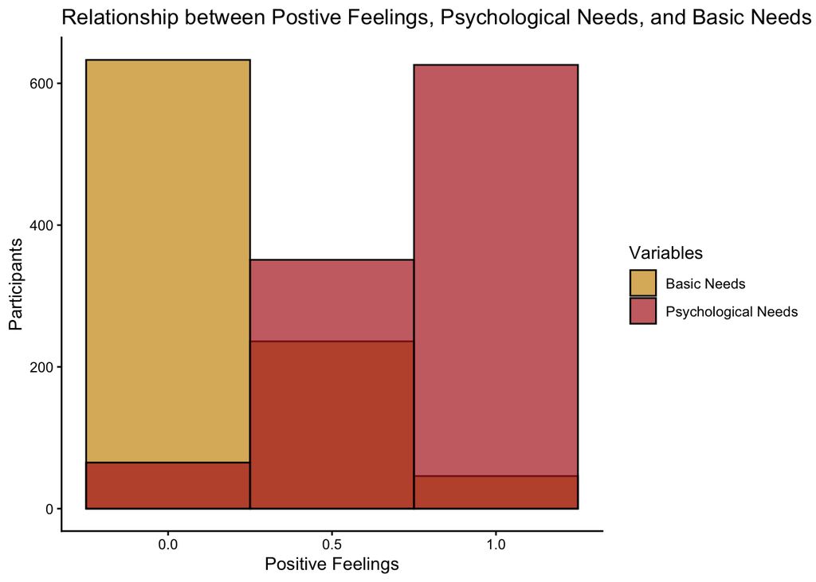

```r
#graph of positive feelings ~ Basic Needs
graphDat <- dat

ggplot(graphDat, aes(PositiveFeelings))+
  geom_histogram(aes(BasicNeeds, fill = "Basic Needs"), binwidth = 0.5, color = "black", alpha = 0.7)+
  geom_histogram(aes(PsychNeeds, fill = "Psychological Needs"), binwidth = 0.5, color = "black", alpha = 0.7)+
  theme_classic()+
  labs(title = "Relationship between Postive Feelings, Psychological Needs, and Basic Needs",
       y = "Participants",
       x = "Positive Feelings")+
  scale_fill_manual(values = c("Basic Needs" = "darkgoldenrod3", "Psychological Needs" = "firebrick"),
                    name = "Variables")
```

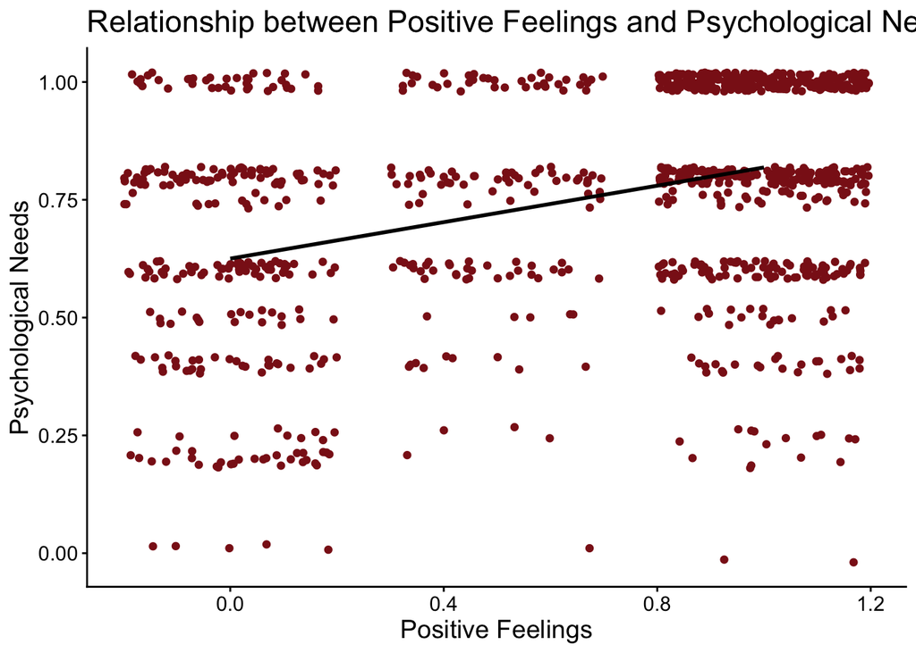

```r
##graphing this another way
ggplot(graphDat, aes(PositiveFeelings, PsychNeeds))+
  geom_jitter(color = "firebrick4")+
  geom_smooth(method = "lm", se = FALSE, color = "black")+
  theme_classic()+
  labs(title = "Relationship between Positive Feelings and Psychological Needs",
       x = "Positive Feelings",
       y = "Psychological Needs")+ theme(text = element_text(size = 14))
```

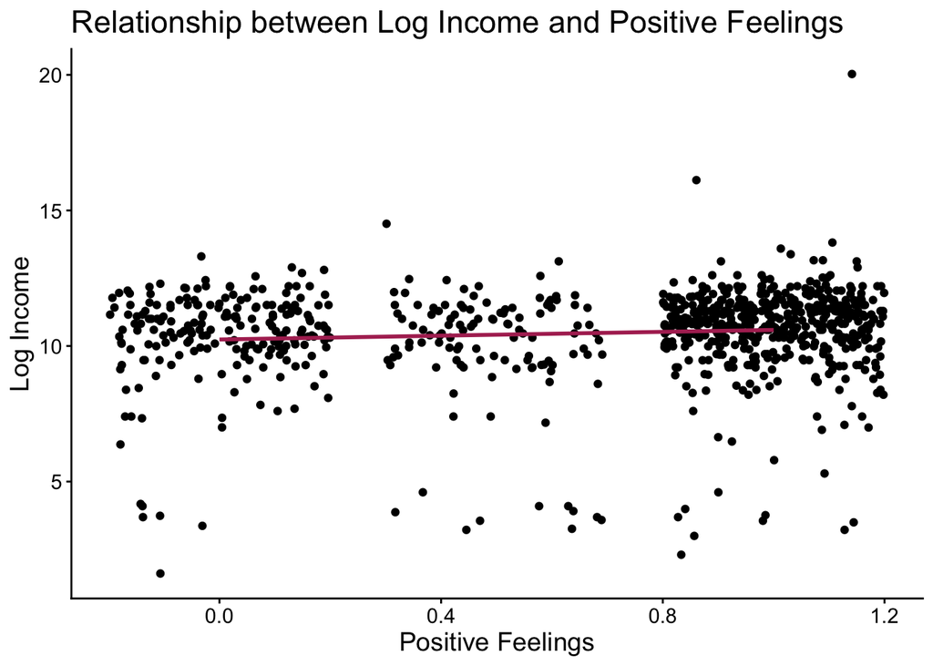

```r
#graph of Income and Positive Feelings
ggplot(graphDat, aes(PositiveFeelings, logIncome))+
  geom_jitter()+
  geom_smooth(method = "lm", se = FALSE, color = "maroon")+
  theme_classic()+
  labs(title = "Relationship between Log Income and Positive Feelings",
       x = "Positive Feelings",
       y = "Log Income")+ theme(text = element_text(size = 14))
```

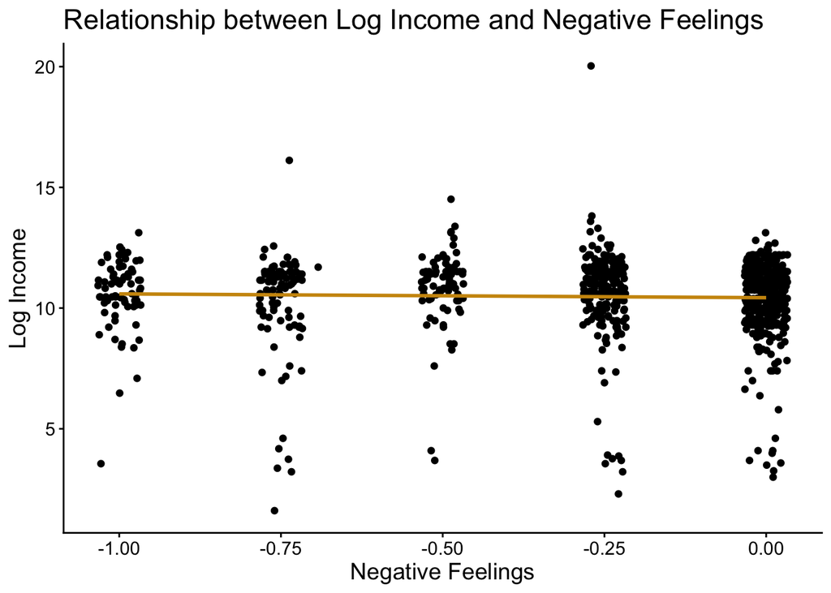

```r
#graph of Negative Feelings and Income
ggplot(graphDat, aes(NegativeFeelings, logIncome))+
  geom_jitter()+
  geom_smooth(method = "lm", se = FALSE, color = "darkgoldenrod3")+
  theme_classic()+
  labs(title = "Relationship between Log Income and Negative Feelings",
       x = "Negative Feelings",
       y = "Log Income")+ theme(text = element_text(size = 14))
```

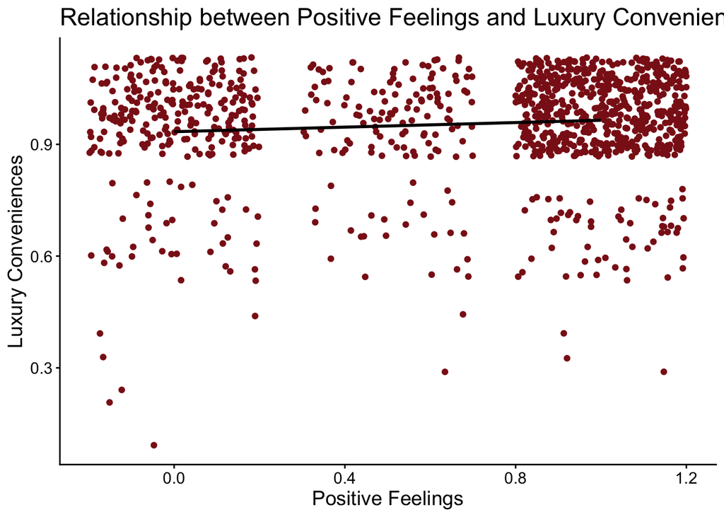

```r
#graph of Positive feelings and luxury items
ggplot(graphDat, aes(PositiveFeelings, LuxuryConveniences))+
  geom_jitter(color = "firebrick4")+
  geom_smooth(method = "lm", se = FALSE, color = "black")+
  theme_classic()+
  labs(title = "Relationship between Positive Feelings and Luxury Conveniences",
       x = "Positive Feelings",
       y = "Luxury Conveniences")+ theme(text = element_text(size = 14))
```

Exporting cleaned dataset to CSV

```r
write.csv(dat, "cleaned_diener_et_al_dataset.csv)", row.names = FALSE)
```